# Shipment

learningSpoons

2018-11-03

- Task 1. 아래에 사용할 패키지를 로드하세요.

```r
library(dplyr)
library(stringr)
library(ggplot2)
library(reshape2)
```

## 1. 불러오기

```r
shipment <- read.csv("shipment.csv", stringsAsFactors = FALSE)
str(shipment)
```

```
## 'data.frame':    1063 obs. of  23 variables:
##  $ X                     : int  651 652 358 437 440 469 541 546 547 549 ...
##  $ 입력일                : chr  "2018-01-02" "2018-01-02" "2018-01-03" "2018-01-03" ...
##  $ 출력일                : chr  "2018-01-02" "2018-01-02" "2018-01-03" "2018-01-03" ...
##  $ 확정일시              : chr  "2018-01-02" "2018-01-02" "2018-01-03" "2018-01-03" ...
##  $ 확정자                : chr  "양희" "양희" "양희" "양희" ...
##  $ 마감일                : chr  "2018-02-04" "2018-02-04" "2018-02-04" "2018-02-04" ...
##  $ 합포                  : chr  "합포" "합포" "합포" "합포" ...
##  $ 주문자                : chr  NA NA NA NA ...
##  $ 수령자                : chr  NA NA NA NA ...
##  $ 우편번호              : chr  "63322" "12784" "21664" "15868" ...
##  $ 주소1                 : chr  NA NA NA NA ...
##  $ 송장번호              : num  3.41e+11 3.41e+11 3.41e+11 3.41e+11 3.41e+11 ...
##  $ 상품수                : int  6 6 3 10 7 7 6 7 7 7 ...
##  $ 로케이션.전상품.      : chr  "C2-2-2-2/C2-2-2-3/C2-3-2-1/C2-4-3-3/" "C2-2-2-2/C2-2-2-3/C2-3-2-1/C2-4-3-3/" "C2-2-2-1/C2-2-2-2/C2-4-3-3/" "C2-2-2-2/C2-2-2-3/C2-2-3-2/C2-2-4-2/C2-3-2-1/C2-3-3-2/C2-4-3-3/C2-4-3-4/C2-5-3-1/" ...
##  $ 브랜드수              : int  1 1 1 1 1 1 1 1 1 1 ...
##  $ 품번                  : chr  "17PERFUME1M|FREE|120ml*002/17PERFUME2S|FREE|120ml*002/17PERFUME3F|FREE|120ml*001/CATALOGK17|FREE|ONE*001/" "17PERFUME1M|FREE|120ml*002/17PERFUME2S|FREE|120ml*002/17PERFUME3F|FREE|120ml*001/CATALOGK17|FREE|ONE*001/" "17PERFUME2S|FREE|120ml*001/18CHEBOTTLE|FREE|FREE*0…
##  $ 색상.최소값.          : chr  "FREE" "FREE" "FREE" "FREE" ...
##  $ 사이즈.최소값.        : chr  "120ml" "120ml" "120ml" "120ml" ...
##  $ 배송메모              : chr  NA NA NA NA ...
##  $ 오클릭주문번호.최소값.: chr  "Z20180102021530" "Z20180102021531" "Z20180103126698" "Z20180103126722" ...
##  $ 판매처주문번호.최소값.: chr  "20171230-0000001" "20171230-0000000" "20180103-0000010" "20171231-0000081" ...
##  $ 브랜드_최소값         : chr  "A" "A" "A" "A" ...
##  $ 판매처                : chr  "A" "A" "A" "A" ...
```

## 2. 전처리

- Task 2. 변수들을 필요에 따라 `Date`, `factor`등으로 변경하세요.

## 3. 그래픽 (Part 1)

- Task 3. 판매량 추이
- Task 4. 채널별 판매량 추이

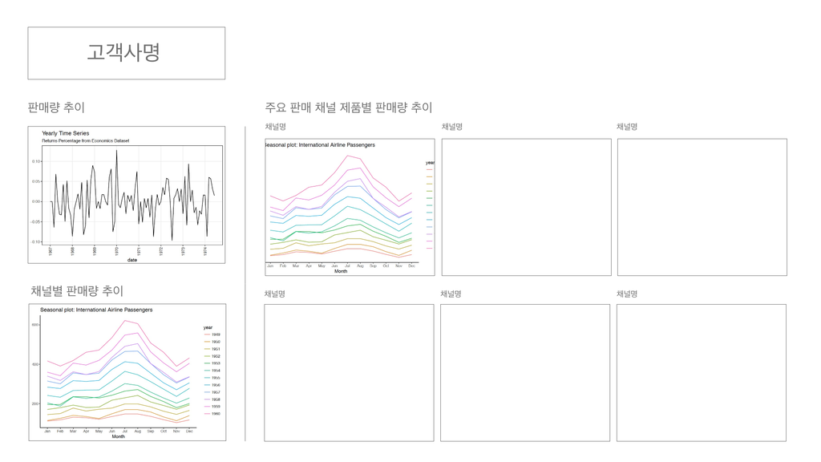

## 4. 그래픽 (Part 2)

- Task 5. 제품별 판매량 비교
- Task 6. 월별 판매 제품 비율
- Task 7. 판매자별 제품 판매량 추이

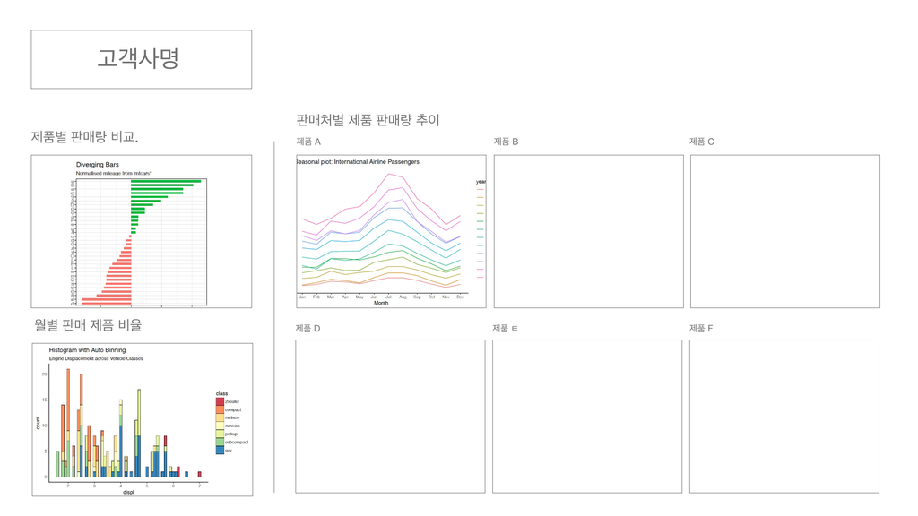

## 5. 분석

- 고객의 구매 패턴을 파악하여 SNS 마케팅 전략 수립하기
- 특정 상품의 판매 주기와 지역별 수요를 파악하여 재고 관리 전략 수립하기
- 매출 추이를 확인하고 간단한 매출 목표 수립하기
- 동시 구매가 많이 일어나는 상품을 파악하여 프로모션 기획
- 배송 메모 텍스트 분석

## 6. Sim - 동시 구매 상품 처리

- (이 분석은 전처리 난이도 상급에 해당합니다.)
- Fact
1. 품번과 품명은 1:1로 대응된다. - 이전 파일에서 `unique(shipment$품번)`와 `unique(shipment$품명)`을 실행해보면 알 수 있음.
2. 첫 번째 관찰값을 살펴보면, `head(shipment$품번, 1)=` 17PERFUME1M|FREE|120ml*002/17PERFUME2S|FREE|120ml*002/17PERFUME3F|FREE|120ml*001/CATALOGK17|FREE|ONE*001/ 이므로, 각각의 아이템에 대해서 “/”로 구분되어 있다는 것을 알 수 있다.

```r
head(shipment$품번, 1)
```

```
## [1] "17PERFUME1M|FREE|120ml*002/17PERFUME2S|FREE|120ml*002/17PERFUME3F|FREE|120ml*001/CATALOGK17|FREE|ONE*001/"
```

- Fact
3. 구분자는 “/”이므로, 이를 각각 분리해야 하고, 각각의 구매 기록에 대해서 어떤 아이템이 판매되었는지 본다.

```r
uniqueSKU <- shipment$품번 %>%
  str_split("/") %>% # SPLIT the STRING by the PATTERN ("/")
  unlist() %>% unique() # unlist everything and find the distinct elements
head(uniqueSKU)
```

```
## [1] "17PERFUME1M|FREE|120ml*002" "17PERFUME2S|FREE|120ml*002"
## [3] "17PERFUME3F|FREE|120ml*001" "CATALOGK17|FREE|ONE*001"
## [5] ""                           "17PERFUME2S|FREE|120ml*001"
```

5. 아! 이해했다! “품번”은 `"SKU" + "|FREE|" + blahblah + "*" + 수량`으로 되어있으며, 동시 구매 상품을 파악하기 위해서는 `"SKU"` (Stock Keeping Number)부분을 떼어서 분석해야 한다.
6. 그렇다면, 다음과 같은 명령으로 진정한 의미의 `uniqueSKU`를 찾아낼 수 있다.

```r
uniqueSKU <- uniqueSKU %>%
  str_split("[|]") %>% # SPLIT the STRING by the PATTERN ("|")
  lapply(function(x) x[1]) %>% # From each VECTOR in a LIST, TAKE the FIRST element
  unlist() %>% unique() # unlist everything and find the distinct elements
uniqueSKU <- uniqueSKU[!uniqueSKU==""]
uniqueSKU
```

```
##  [1] "17PERFUME1M"  "17PERFUME2S"  "17PERFUME3F"  "CATALOGK17"
##  [5] "18CHEBOTTLE"  "17CLAPO10LB"  "17CLAPO10SM"  "17CLAPO10VE"
##  [9] "17CLAPO10WO"  "CATALOEN17"   "17CLAPO10SA"  "17CLAPO10FM"
## [13] "17CLAPO10SP"  "17CLAPO10MA"  "17CLAPO10MO"  "17CLAPO10CH"
## [17] "17CLAPO10BO"  "17LOZIP30BS"  "17LOZIP30CH"  "17LOZIP30MO"
## [21] "17LOZIP30WO"  "17LOZIP30LB"  "000000"       "17LOZIP30SM"
## [25] "17LOZIP30VE"  "16PROMTRIFL"  "16PROMTRIMI"  "16PROMTRISP"
## [29] "16PROMTRIVE"  "16PROMTRIBO"  "17WHITEBAG"   "16PROM30CH"
## [33] "16PROM30MO"   "16PROM30VE"   "16PROM30FL"   "16PROM30MI"
## [37] "16PROM30SE"   "16PROM30BO"   "16PROM30WO"   "16PROMTRISE"
## [41] "16PROMTRISPP" "16PROMTRICH"  "16PROMTRIMO"  "17LOZIP30MA"
## [45] "17LOZIP30BO"  "18MONTHS20A"  "18TNTPSETOA"  "18TNTPSETOB"
## [49] "18TNTPSETOC"  "17LOZIP30FL"  "18CLAPO10BS"
```

- Task Specification
1. `GGplot-50examples`의 12페이지를 우선 이해하세요.
2. 해당 예제에서는 `corr`이라는 객체를 생성하고, 그림을 그립니다.
3. `corr`의 객체를 예제를 paste하여 생성해보세요. 어떤 구조인가요?

```r
# from M91
data(mtcars)
corr <- round(cor(mtcars), 1)
corr
```

[output not shown]

4. 이와 같이 우리는 우선 한변이 uniqueSKU의 길이가 되는 정사각형의 데이터 구조를 만들고 동시 구매 횟수를 기록해야 합니다.
5. 그 이후로 그림은 뭔가 비슷한 방법을 이용해서 그리면 되겠죠?
6. 우선 우리의 데이터로 “정사각표”를 만들어 보겠습니다.

```r
purchase <- array(0, c(length(uniqueSKU), length(uniqueSKU)))
colnames(purchase) <- uniqueSKU
rownames(purchase) <- uniqueSKU
for (i in 1:length(uniqueSKU)) {
  for (j in 1:length(uniqueSKU)) {
    purchase[i,j] <-
      sum(str_detect(shipment$품번, uniqueSKU[i]) & str_detect(shipment$품번, uniqueSKU[j]))
  }
}
```

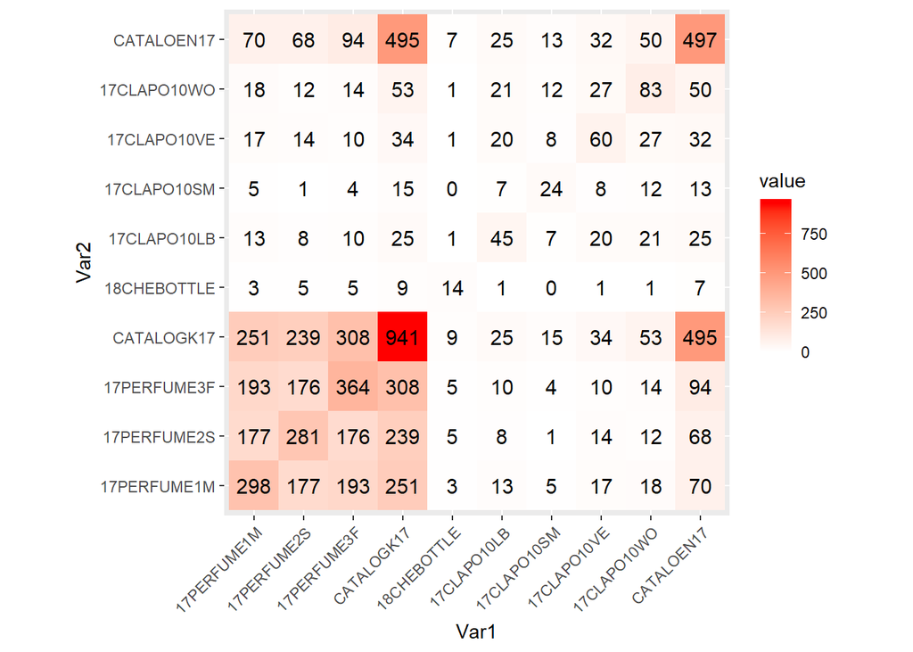

```r
purchaseSet1 <- purchase[1:10,1:10]
ggplot(melt(purchaseSet1), aes(Var1, Var2, fill = value, label = value)) +
  geom_tile() +
  geom_text(size=4) +
  scale_fill_gradient2(low="blue", mid="white", high="red") +
  theme(axis.text.x = element_text(angle = 45, hjust = 1)) +
  coord_equal()
```

```r
## Further readings:
## https://www.worldfullofdata.com/code-visualize-correlation-matrix-r/
```